# Project: Investigate Gapminder World Dataset

- Introduction
- Data Wrangling
- Exploratory Data Analysis
- Conclusions

## Introduction

### Dataset Description

This data contains three data sets of 186 countries in three main indicators :-

1) population  
2) life exectancy  
3) income per person

and this data is represnted from year 1800 to year 2050.

### Question(s) for Analysis

•Is average population of all countries increase by years in past 100 years ?  
•Is expected that population will increase in following years ?  
•Is average income per person of all countries increase by years in past 100 years ?  
•Is expected that income per person will increase in following years ?  
•Is average life expectancy of all countries increase by years in past 100 years ?  
•Is expected that life expectancy will increase in following years ?  
•What is the relationship between income indicator and population and life expectancy indicators ?

```python
import pandas as pd
import matplotlib.pyplot as plt
% matplotlib inline
```

```python
# Upgrade pandas to use dataframe.explode() function.
!pip install --upgrade pandas==0.25.0
```

[output not shown]

## Data Wrangling

> view shape of data set and data types and some rows

```python
df_income=pd.read_csv('income_per_person_gdppercapita_ppp_inflation_adjusted.csv')
df_life=pd.read_csv('life_expectancy_years.csv')
df_population=pd.read_csv('population_total.csv')
```

```python
df_life.shape,df_income.shape,df_population.shape
```

```
((195, 302), (195, 252), (197, 302))
```

So we have found that we don't have the same rows and columns so we will explore some rows to have better understanding

```python
df_income.head()
```

|  | country | 1800 | 1801 | 1802 | 1803 | 1804 | 1805 | 1806 | 1807 | 1808 | ... | 2041 | 2042 | 2043 | 2044 | 2045 | 2046 | 2047 | 2048 | 2049 | 2050 |
| --- | --- | --- | --- | --- | --- | --- | --- | --- | --- | --- | --- | --- | --- | --- | --- | --- | --- | --- | --- | --- | --- |
| 0 | Afghanistan | 683 | 683 | 683 | 683 | 683 | 683 | 683 | 683 | 683 | ... | 2690 | 2750 | 2810 | 2870 | 2930 | 2990 | 3060 | 3120 | 3190 | 3260 |
| 1 | Angola | 700 | 702 | 705 | 709 | 711 | 714 | 718 | 721 | 725 | ... | 8000 | 8170 | 8350 | 8530 | 8710 | 8900 | 9090 | 9280 | 9480 | 9690 |
| 2 | Albania | 755 | 755 | 755 | 755 | 755 | 756 | 756 | 756 | 756 | ... | 25.1k | 25.6k | 26.2k | 26.7k | 27.3k | 27.9k | 28.5k | 29.1k | 29.7k | 30.4k |
| 3 | Andorra | 1360 | 1360 | 1360 | 1360 | 1370 | 1370 | 1370 | 1370 | 1380 | ... | 68.9k | 70.4k | 71.9k | 73.4k | 75k | 76.6k | 78.3k | 80k | 81.7k | 83.4k |
| 4 | United Arab Emirates | 1130 | 1130 | 1140 | 1140 | 1150 | 1150 | 1160 | 1160 | 1160 | ... | 101k | 103k | 105k | 107k | 110k | 112k | 114k | 117k | 119k | 122k |

5 rows × 252 columns

```python
df_life.head()
```

|  | country | 1800 | 1801 | 1802 | 1803 | 1804 | 1805 | 1806 | 1807 | 1808 | ... | 2091 | 2092 | 2093 | 2094 | 2095 | 2096 | 2097 | 2098 | 2099 | 2100 |
| --- | --- | --- | --- | --- | --- | --- | --- | --- | --- | --- | --- | --- | --- | --- | --- | --- | --- | --- | --- | --- | --- |
| 0 | Afghanistan | 28.2 | 28.2 | 28.2 | 28.2 | 28.2 | 28.2 | 28.1 | 28.1 | 28.1 | ... | 75.5 | 75.7 | 75.8 | 76.0 | 76.1 | 76.2 | 76.4 | 76.5 | 76.6 | 76.8 |
| 1 | Angola | 27.0 | 27.0 | 27.0 | 27.0 | 27.0 | 27.0 | 27.0 | 27.0 | 27.0 | ... | 78.8 | 79.0 | 79.1 | 79.2 | 79.3 | 79.5 | 79.6 | 79.7 | 79.9 | 80.0 |
| 2 | Albania | 35.4 | 35.4 | 35.4 | 35.4 | 35.4 | 35.4 | 35.4 | 35.4 | 35.4 | ... | 87.4 | 87.5 | 87.6 | 87.7 | 87.8 | 87.9 | 88.0 | 88.2 | 88.3 | 88.4 |
| 3 | Andorra | NaN | NaN | NaN | NaN | NaN | NaN | NaN | NaN | NaN | ... | NaN | NaN | NaN | NaN | NaN | NaN | NaN | NaN | NaN | NaN |
| 4 | United Arab Emirates | 30.7 | 30.7 | 30.7 | 30.7 | 30.7 | 30.7 | 30.7 | 30.7 | 30.7 | ... | 82.4 | 82.5 | 82.6 | 82.7 | 82.8 | 82.9 | 83.0 | 83.1 | 83.2 | 83.3 |

5 rows × 302 columns

```python
df_population.head()
```

|  | country | 1800 | 1801 | 1802 | 1803 | 1804 | 1805 | 1806 | 1807 | 1808 | ... | 2091 | 2092 | 2093 | 2094 | 2095 | 2096 | 2097 | 2098 | 2099 | 2100 |
| --- | --- | --- | --- | --- | --- | --- | --- | --- | --- | --- | --- | --- | --- | --- | --- | --- | --- | --- | --- | --- | --- |
| 0 | Afghanistan | 3.28M | 3.28M | 3.28M | 3.28M | 3.28M | 3.28M | 3.28M | 3.28M | 3.28M | ... | 76.6M | 76.4M | 76.3M | 76.1M | 76M | 75.8M | 75.6M | 75.4M | 75.2M | 74.9M |
| 1 | Angola | 1.57M | 1.57M | 1.57M | 1.57M | 1.57M | 1.57M | 1.57M | 1.57M | 1.57M | ... | 168M | 170M | 172M | 175M | 177M | 179M | 182M | 184M | 186M | 188M |
| 2 | Albania | 400k | 402k | 404k | 405k | 407k | 409k | 411k | 413k | 414k | ... | 1.33M | 1.3M | 1.27M | 1.25M | 1.22M | 1.19M | 1.17M | 1.14M | 1.11M | 1.09M |
| 3 | Andorra | 2650 | 2650 | 2650 | 2650 | 2650 | 2650 | 2650 | 2650 | 2650 | ... | 63k | 62.9k | 62.9k | 62.8k | 62.7k | 62.7k | 62.6k | 62.5k | 62.5k | 62.4k |
| 4 | United Arab Emirates | 40.2k | 40.2k | 40.2k | 40.2k | 40.2k | 40.2k | 40.2k | 40.2k | 40.2k | ... | 12.3M | 12.4M | 12.5M | 12.5M | 12.6M | 12.7M | 12.7M | 12.8M | 12.8M | 12.9M |

5 rows × 302 columns

Checking of the three have the same data types

```python
df_income.info()
```

```
<class 'pandas.core.frame.DataFrame'>
RangeIndex: 195 entries, 0 to 194
Columns: 252 entries, country to 2050
dtypes: int64(101), object(151)
memory usage: 384.0+ KB
```

```python
df_life.info()
```

```
<class 'pandas.core.frame.DataFrame'>
RangeIndex: 195 entries, 0 to 194
Columns: 302 entries, country to 2100
dtypes: float64(301), object(1)
memory usage: 460.2+ KB
```

```python
df_population.info()
```

```
<class 'pandas.core.frame.DataFrame'>
RangeIndex: 197 entries, 0 to 196
Columns: 302 entries, country to 2100
dtypes: object(302)
memory usage: 464.9+ KB
```

Checking if the data set have any nan values

```python
df_income.isnull().sum().sum(),df_population.isnull().sum().sum(),df_life.isnull().any(axis=1).sum()
```

```
(0, 0, 9)
```

Checking if the data set have any duplication

```python
df_income.duplicated().sum(),df_life.duplicated().sum(),df_population.duplicated().sum()
```

```
(0, 0, 0)
```

### Data Cleaning

> So as we have seen above we don't have same rows, columns and data types and we have also nan values all those need to be fixed

First removing all excess columns

```python
def column_equalizer (x,y):
    for column in y.columns:
        if column not in x.columns:
            y.drop(column,axis=1,inplace=True)
column_equalizer (df_income,df_life)
column_equalizer (df_income,df_population)
```

Making sure that we have the same number of columns

```python
df_life.shape,df_income.shape,df_population.shape
```

```
((195, 252), (195, 252), (197, 252))
```

Second removing excess rows

If life and income dataframe has the same country names , we don't need to make for loop twice

```python
list(df_life['country'])==list(df_income['country'])
```

```
True
```

```python
z=[]
for country in list(df_population['country']):
    if country not in list(df_life['country']):
        z.append(country)
z
```

```
['Holy See', 'Liechtenstein']
```

```python
new_population=df_population.query('country==["Holy See", "Liechtenstein"]')
df_population.drop(new_population.index,axis=0,inplace=True)
```

Making sure that we have the same columns names

```python
list(df_life['country'])==list(df_population['country']),list(df_income['country'])==list(df_population['country']),list(df_life['country'])==list(df_income['country'])
```

```
(True, True, True)
```

third removing nan cells from life dataframe, but before removing them we need to know country names that have these nan values to remove them also from income dataframe and population dataframe

```python
list(df_life[df_life.isnull().any(axis=1)]['country'])
```

```
['Andorra',
 'Dominica',
 'St. Kitts and Nevis',
 'Monaco',
 'Marshall Islands',
 'Nauru',
 'Palau',
 'San Marino',
 'Tuvalu']
```

```python
def country_equalizer(x):
    country_filter=x.query('country==["Andorra","Dominica","St. Kitts and Nevis","Monaco","Marshall Islands","Nauru","Palau","San Marino","Tuvalu"]')
    x.drop(country_filter.index,axis=0,inplace=True)

country_equalizer(df_population)
country_equalizer(df_income)
```

```python
df_life.dropna(axis=0,inplace=True)
```

Making sure that we don't have any nan values

```python
df_income.isnull().sum().sum(),df_population.isnull().sum().sum(),df_life.isnull().any(axis=1).sum()
```

```
(0, 0, 0)
```

Making sure that we have the same country names in all dataframes

```python
list(df_life['country'])==list(df_population['country']),list(df_income['country'])==list(df_population['country']),list(df_life['country'])==list(df_income['country'])
```

```
(True, True, True)
```

Fourth Fixing data types,We need more investagations in each dataframe

```python
df_income
```

|  | country | 1800 | 1801 | 1802 | 1803 | 1804 | 1805 | 1806 | 1807 | 1808 | ... | 2041 | 2042 | 2043 | 2044 | 2045 | 2046 | 2047 | 2048 | 2049 | 2050 |
| --- | --- | --- | --- | --- | --- | --- | --- | --- | --- | --- | --- | --- | --- | --- | --- | --- | --- | --- | --- | --- | --- |
| 0 | Afghanistan | 683 | 683 | 683 | 683 | 683 | 683 | 683 | 683 | 683 | ... | 2690 | 2750 | 2810 | 2870 | 2930 | 2990 | 3060 | 3120 | 3190 | 3260 |
| 1 | Angola | 700 | 702 | 705 | 709 | 711 | 714 | 718 | 721 | 725 | ... | 8000 | 8170 | 8350 | 8530 | 8710 | 8900 | 9090 | 9280 | 9480 | 9690 |
| 2 | Albania | 755 | 755 | 755 | 755 | 755 | 756 | 756 | 756 | 756 | ... | 25.1k | 25.6k | 26.2k | 26.7k | 27.3k | 27.9k | 28.5k | 29.1k | 29.7k | 30.4k |
| 4 | United Arab Emirates | 1130 | 1130 | 1140 | 1140 | 1150 | 1150 | 1160 | 1160 | 1160 | ... | 101k | 103k | 105k | 107k | 110k | 112k | 114k | 117k | 119k | 122k |
| 5 | Argentina | 1730 | 1730 | 1740 | 1740 | 1750 | 1760 | 1760 | 1770 | 1770 | ... | 30.5k | 31.1k | 31.8k | 32.5k | 33.2k | 33.9k | 34.7k | 35.4k | 36.2k | 36.9k |
| 6 | Armenia | 582 | 582 | 582 | 582 | 582 | 582 | 582 | 582 | 582 | ... | 24.7k | 25.2k | 25.8k | 26.3k | 26.9k | 27.5k | 28.1k | 28.7k | 29.3k | 29.9k |
| 7 | Antigua and Barbuda | 857 | 857 | 857 | 857 | 857 | 857 | 857 | 858 | 858 | ... | 26.4k | 27k | 27.6k | 28.1k | 28.8k | 29.4k | 30k | 30.7k | 31.3k | 32k |
| 8 | Australia | 925 | 930 | 936 | 941 | 947 | 952 | 956 | 962 | 968 | ... | 72k | 73.5k | 75.1k | 76.7k | 78.4k | 80.1k | 81.8k | 83.5k | 85.3k | 87.2k |
| 9 | Austria | 2090 | 2100 | 2110 | 2120 | 2130 | 2130 | 2140 | 2150 | 2160 | ... | 77.8k | 79.5k | 81.2k | 83k | 84.7k | 86.6k | 88.4k | 90.3k | 92.3k | 94.3k |
| 10 | Azerbaijan | 877 | 877 | 877 | 877 | 877 | 878 | 878 | 878 | 878 | ... | 20.3k | 20.8k | 21.2k | 21.7k | 22.2k | 22.6k | 23.1k | 23.6k | 24.1k | 24.6k |
| 11 | Burundi | 473 | 473 | 474 | 474 | 475 | 475 | 475 | 477 | 477 | ... | 1050 | 1070 | 1100 | 1120 | 1140 | 1170 | 1190 | 1220 | 1240 | 1270 |
| 12 | Belgium | 2700 | 2700 | 2700 | 2710 | 2710 | 2720 | 2720 | 2720 | 2730 | ... | 70.3k | 71.9k | 73.4k | 75k | 76.6k | 78.3k | 79.9k | 81.7k | 83.4k | 85.2k |
| 13 | Benin | 676 | 676 | 676 | 676 | 676 | 676 | 676 | 676 | 676 | ... | 5790 | 5910 | 6040 | 6170 | 6300 | 6440 | 6580 | 6720 | 6860 | 7010 |
| 14 | Burkina Faso | 543 | 543 | 543 | 543 | 543 | 543 | 543 | 543 | 543 | ... | 3460 | 3530 | 3610 | 3680 | 3760 | 3840 | 3930 | 4010 | 4100 | 4190 |
| 15 | Bangladesh | 992 | 992 | 992 | 992 | 992 | 992 | 992 | 992 | 992 | ... | 11.1k | 11.3k | 11.5k | 11.8k | 12k | 12.3k | 12.6k | 12.8k | 13.1k | 13.4k |
| 16 | Bulgaria | 1230 | 1230 | 1230 | 1230 | 1230 | 1230 | 1230 | 1230 | 1230 | ... | 42.1k | 43k | 43.9k | 44.8k | 45.8k | 46.8k | 47.8k | 48.8k | 49.9k | 50.9k |
| 17 | Bahrain | 1400 | 1400 | 1410 | 1420 | 1420 | 1430 | 1430 | 1440 | 1450 | ... | 60.1k | 61.4k | 62.7k | 64.1k | 65.5k | 66.9k | 68.3k | 69.8k | 71.3k | 72.8k |
| 18 | Bahamas | 1640 | 1640 | 1640 | 1640 | 1640 | 1640 | 1640 | 1640 | 1640 | ... | 45.3k | 46.3k | 47.3k | 48.3k | 49.3k | 50.4k | 51.5k | 52.6k | 53.7k | 54.9k |
| 19 | Bosnia and Herzegovina | 757 | 757 | 757 | 757 | 757 | 757 | 757 | 757 | 757 | ... | 25.8k | 26.3k | 26.9k | 27.5k | 28.1k | 28.7k | 29.3k | 29.9k | 30.6k | 31.2k |
| 20 | Belarus | 688 | 688 | 688 | 689 | 689 | 689 | 691 | 691 | 691 | ... | 25.8k | 26.3k | 26.9k | 27.5k | 28.1k | 28.7k | 29.3k | 29.9k | 30.5k | 31.2k |
| 21 | Belize | 655 | 655 | 655 | 655 | 655 | 655 | 655 | 655 | 655 | ... | 8170 | 8340 | 8520 | 8710 | 8900 | 9090 | 9280 | 9480 | 9690 | 9900 |
| 22 | Bolivia | 967 | 967 | 967 | 967 | 967 | 967 | 967 | 967 | 968 | ... | 12.4k | 12.7k | 13k | 13.3k | 13.5k | 13.8k | 14.1k | 14.4k | 14.8k | 15.1k |
| 23 | Brazil | 1010 | 1010 | 1010 | 1010 | 1010 | 1010 | 1010 | 1010 | 1010 | ... | 19.8k | 20.2k | 20.6k | 21.1k | 21.5k | 22k | 22.5k | 22.9k | 23.4k | 23.9k |
| 24 | Barbados | 1030 | 1040 | 1040 | 1040 | 1040 | 1040 | 1040 | 1040 | 1040 | ... | 22.7k | 23.2k | 23.7k | 24.2k | 24.7k | 25.3k | 25.8k | 26.4k | 26.9k | 27.5k |
| 25 | Brunei | 1710 | 1710 | 1710 | 1710 | 1710 | 1710 | 1710 | 1710 | 1710 | ... | 98.3k | 100k | 103k | 105k | 107k | 109k | 112k | 114k | 117k | 119k |
| 26 | Bhutan | 712 | 712 | 713 | 713 | 713 | 713 | 713 | 713 | 713 | ... | 21.2k | 21.6k | 22.1k | 22.6k | 23.1k | 23.6k | 24.1k | 24.6k | 25.1k | 25.6k |
| 27 | Botswana | 449 | 449 | 449 | 449 | 449 | 451 | 451 | 451 | 451 | ... | 24.1k | 24.6k | 25.2k | 25.7k | 26.3k | 26.8k | 27.4k | 28k | 28.6k | 29.2k |
| 28 | Central African Republic | 480 | 480 | 480 | 480 | 480 | 480 | 480 | 481 | 481 | ... | 1420 | 1450 | 1480 | 1510 | 1540 | 1570 | 1610 | 1640 | 1680 | 1710 |
| 29 | Canada | 1490 | 1500 | 1510 | 1520 | 1530 | 1530 | 1540 | 1550 | 1560 | ... | 65.2k | 66.6k | 68.1k | 69.5k | 71k | 72.6k | 74.1k | 75.7k | 77.4k | 79k |
| 30 | Switzerland | 2770 | 2770 | 2770 | 2770 | 2770 | 2780 | 2780 | 2780 | 2780 | ... | 94k | 96k | 98.1k | 100k | 102k | 105k | 107k | 109k | 111k | 114k |
| ... | ... | ... | ... | ... | ... | ... | ... | ... | ... | ... | ... | ... | ... | ... | ... | ... | ... | ... | ... | ... | ... |
| 164 | Sweden | 1590 | 1570 | 1650 | 1630 | 1530 | 1620 | 1640 | 1570 | 1490 | ... | 74.5k | 76.1k | 77.7k | 79.4k | 81.1k | 82.8k | 84.6k | 86.5k | 88.3k | 90.2k |
| 165 | Eswatini | 555 | 555 | 555 | 555 | 555 | 555 | 555 | 555 | 555 | ... | 11.9k | 12.1k | 12.4k | 12.7k | 12.9k | 13.2k | 13.5k | 13.8k | 14.1k | 14.4k |
| 166 | Seychelles | 897 | 900 | 903 | 907 | 910 | 914 | 918 | 921 | 925 | ... | 48.2k | 49.3k | 50.3k | 51.4k | 52.5k | 53.7k | 54.8k | 56k | 57.2k | 58.4k |
| 167 | Syria | 1260 | 1260 | 1260 | 1260 | 1260 | 1260 | 1260 | 1260 | 1260 | ... | 5870 | 6000 | 6130 | 6260 | 6390 | 6530 | 6670 | 6810 | 6960 | 7110 |
| 168 | Chad | 473 | 473 | 473 | 473 | 473 | 473 | 473 | 474 | 474 | ... | 1910 | 1950 | 1990 | 2030 | 2080 | 2120 | 2170 | 2210 | 2260 | 2310 |
| 169 | Togo | 772 | 773 | 773 | 773 | 773 | 773 | 773 | 773 | 773 | ... | 3870 | 3960 | 4040 | 4130 | 4220 | 4310 | 4400 | 4500 | 4590 | 4690 |
| 170 | Thailand | 1060 | 1060 | 1060 | 1060 | 1060 | 1060 | 1060 | 1060 | 1060 | ... | 29.8k | 30.4k | 31.1k | 31.7k | 32.4k | 33.1k | 33.8k | 34.6k | 35.3k | 36.1k |
| 171 | Tajikistan | 629 | 631 | 631 | 631 | 631 | 631 | 632 | 632 | 632 | ... | 5980 | 6110 | 6240 | 6370 | 6510 | 6650 | 6790 | 6940 | 7090 | 7240 |
| 172 | Turkmenistan | 1070 | 1070 | 1070 | 1070 | 1070 | 1070 | 1080 | 1080 | 1080 | ... | 20.2k | 20.6k | 21.1k | 21.5k | 22k | 22.5k | 23k | 23.4k | 24k | 24.5k |
| 173 | Timor-Leste | 590 | 591 | 592 | 593 | 594 | 595 | 597 | 598 | 599 | ... | 3790 | 3880 | 3960 | 4040 | 4130 | 4220 | 4310 | 4400 | 4500 | 4600 |
| 174 | Tonga | 751 | 751 | 751 | 751 | 751 | 751 | 751 | 751 | 751 | ... | 9520 | 9720 | 9930 | 10.1k | 10.4k | 10.6k | 10.8k | 11k | 11.3k | 11.5k |
| 175 | Trinidad and Tobago | 1390 | 1390 | 1390 | 1390 | 1390 | 1390 | 1390 | 1390 | 1400 | ... | 33.5k | 34.3k | 35k | 35.8k | 36.5k | 37.3k | 38.1k | 38.9k | 39.8k | 40.6k |
| 176 | Tunisia | 801 | 800 | 800 | 800 | 800 | 799 | 799 | 799 | 799 | ... | 13.5k | 13.8k | 14.1k | 14.4k | 14.7k | 15k | 15.3k | 15.7k | 16k | 16.4k |
| 177 | Turkey | 1120 | 1120 | 1120 | 1120 | 1120 | 1120 | 1120 | 1120 | 1120 | ... | 47.9k | 49k | 50k | 51.1k | 52.2k | 53.3k | 54.5k | 55.6k | 56.8k | 58.1k |
| 179 | Taiwan | 1120 | 1120 | 1120 | 1120 | 1120 | 1120 | 1120 | 1120 | 1120 | ... | 92.4k | 94.4k | 96.4k | 98.5k | 101k | 103k | 105k | 107k | 110k | 112k |
| 180 | Tanzania | 636 | 636 | 636 | 636 | 636 | 636 | 637 | 637 | 637 | ... | 4450 | 4550 | 4640 | 4740 | 4850 | 4950 | 5060 | 5170 | 5280 | 5390 |
| 181 | Uganda | 525 | 525 | 525 | 525 | 525 | 525 | 525 | 525 | 525 | ... | 3420 | 3500 | 3570 | 3650 | 3730 | 3810 | 3890 | 3970 | 4060 | 4150 |
| 182 | Ukraine | 864 | 865 | 866 | 867 | 868 | 868 | 869 | 871 | 872 | ... | 23.2k | 23.7k | 24.2k | 24.7k | 25.3k | 25.8k | 26.4k | 26.9k | 27.5k | 28.1k |
| 183 | Uruguay | 2140 | 2150 | 2150 | 2160 | 2170 | 2180 | 2190 | 2190 | 2200 | ... | 34.5k | 35.3k | 36k | 36.8k | 37.6k | 38.4k | 39.3k | 40.1k | 41k | 41.8k |
| 184 | United States | 2960 | 3010 | 3060 | 3010 | 3010 | 3070 | 3130 | 3160 | 2940 | ... | 90.4k | 92.3k | 94.3k | 96.4k | 98.4k | 101k | 103k | 105k | 107k | 110k |
| 185 | Uzbekistan | 568 | 568 | 568 | 568 | 569 | 569 | 569 | 569 | 569 | ... | 13k | 13.3k | 13.6k | 13.8k | 14.1k | 14.4k | 14.8k | 15.1k | 15.4k | 15.7k |
| 186 | St. Vincent and the Grenadines | 949 | 949 | 949 | 949 | 949 | 950 | 950 | 950 | 950 | ... | 20k | 20.4k | 20.9k | 21.3k | 21.8k | 22.3k | 22.7k | 23.2k | 23.7k | 24.2k |
| 187 | Venezuela | 1250 | 1240 | 1240 | 1230 | 1220 | 1220 | 1210 | 1200 | 1200 | ... | 1710 | 1740 | 1780 | 1820 | 1860 | 1900 | 1940 | 1980 | 2020 | 2070 |
| 188 | Vietnam | 976 | 976 | 976 | 976 | 976 | 976 | 976 | 976 | 976 | ... | 18.3k | 18.7k | 19.1k | 19.5k | 19.9k | 20.3k | 20.8k | 21.2k | 21.7k | 22.1k |
| 189 | Vanuatu | 662 | 663 | 663 | 663 | 663 | 663 | 663 | 663 | 663 | ... | 3330 | 3410 | 3480 | 3550 | 3630 | 3710 | 3790 | 3870 | 3950 | 4040 |
| 190 | Samoa | 1590 | 1590 | 1590 | 1590 | 1590 | 1590 | 1590 | 1590 | 1590 | ... | 8860 | 9050 | 9250 | 9440 | 9650 | 9860 | 10.1k | 10.3k | 10.5k | 10.7k |
| 191 | Yemen | 993 | 995 | 998 | 1000 | 1000 | 1010 | 1010 | 1010 | 1020 | ... | 3750 | 3830 | 3910 | 3990 | 4080 | 4170 | 4260 | 4350 | 4440 | 4540 |
| 192 | South Africa | 1780 | 1760 | 1740 | 1720 | 1700 | 1610 | 1610 | 1750 | 1530 | ... | 16.2k | 16.6k | 16.9k | 17.3k | 17.7k | 18.1k | 18.5k | 18.8k | 19.3k | 19.7k |
| 193 | Zambia | 751 | 753 | 755 | 756 | 758 | 760 | 762 | 764 | 765 | ... | 4690 | 4790 | 4890 | 5000 | 5110 | 5220 | 5330 | 5440 | 5560 | 5680 |
| 194 | Zimbabwe | 984 | 985 | 986 | 987 | 988 | 989 | 991 | 992 | 993 | ... | 4890 | 4990 | 5100 | 5210 | 5320 | 5440 | 5560 | 5670 | 5800 | 5920 |

186 rows × 252 columns

```python
df_life
```

|  | country | 1800 | 1801 | 1802 | 1803 | 1804 | 1805 | 1806 | 1807 | 1808 | ... | 2041 | 2042 | 2043 | 2044 | 2045 | 2046 | 2047 | 2048 | 2049 | 2050 |
| --- | --- | --- | --- | --- | --- | --- | --- | --- | --- | --- | --- | --- | --- | --- | --- | --- | --- | --- | --- | --- | --- |
| 0 | Afghanistan | 28.2 | 28.2 | 28.2 | 28.2 | 28.2 | 28.2 | 28.1 | 28.1 | 28.1 | ... | 68.6 | 68.8 | 68.9 | 69.1 | 69.2 | 69.4 | 69.5 | 69.7 | 69.8 | 70.0 |
| 1 | Angola | 27.0 | 27.0 | 27.0 | 27.0 | 27.0 | 27.0 | 27.0 | 27.0 | 27.0 | ... | 71.4 | 71.6 | 71.8 | 72.0 | 72.2 | 72.4 | 72.5 | 72.7 | 72.9 | 73.1 |
| 2 | Albania | 35.4 | 35.4 | 35.4 | 35.4 | 35.4 | 35.4 | 35.4 | 35.4 | 35.4 | ... | 81.6 | 81.8 | 81.9 | 82.0 | 82.2 | 82.3 | 82.4 | 82.6 | 82.7 | 82.8 |
| 4 | United Arab Emirates | 30.7 | 30.7 | 30.7 | 30.7 | 30.7 | 30.7 | 30.7 | 30.7 | 30.7 | ... | 76.8 | 77.0 | 77.1 | 77.2 | 77.3 | 77.5 | 77.6 | 77.7 | 77.9 | 78.0 |
| 5 | Argentina | 33.2 | 33.2 | 33.2 | 33.2 | 33.2 | 33.2 | 33.2 | 33.2 | 33.2 | ... | 79.8 | 80.0 | 80.1 | 80.3 | 80.4 | 80.6 | 80.7 | 80.8 | 81.0 | 81.2 |
| 6 | Armenia | 34.0 | 34.0 | 34.0 | 34.0 | 34.0 | 34.0 | 34.0 | 34.0 | 34.0 | ... | 78.7 | 78.9 | 79.0 | 79.1 | 79.3 | 79.4 | 79.5 | 79.7 | 79.8 | 79.9 |
| 7 | Antigua and Barbuda | 33.5 | 33.5 | 33.5 | 33.5 | 33.5 | 33.5 | 33.5 | 33.5 | 33.5 | ... | 79.1 | 79.2 | 79.3 | 79.5 | 79.6 | 79.7 | 79.8 | 80.0 | 80.1 | 80.2 |
| 8 | Australia | 34.0 | 34.0 | 34.0 | 34.0 | 34.0 | 34.0 | 34.0 | 34.0 | 34.0 | ... | 85.6 | 85.7 | 85.8 | 86.0 | 86.1 | 86.2 | 86.3 | 86.4 | 86.5 | 86.6 |
| 9 | Austria | 34.4 | 34.4 | 34.4 | 34.4 | 34.4 | 34.4 | 34.4 | 34.4 | 34.4 | ... | 85.4 | 85.5 | 85.6 | 85.8 | 85.9 | 86.0 | 86.1 | 86.2 | 86.3 | 86.5 |
| 10 | Azerbaijan | 29.2 | 29.2 | 29.2 | 29.2 | 29.2 | 29.2 | 29.2 | 29.2 | 29.2 | ... | 73.3 | 73.5 | 73.6 | 73.7 | 73.8 | 73.9 | 74.0 | 74.2 | 74.3 | 74.4 |
| 11 | Burundi | 31.5 | 31.5 | 31.5 | 31.5 | 31.5 | 31.5 | 31.5 | 31.5 | 31.5 | ... | 70.3 | 70.5 | 70.8 | 71.0 | 71.2 | 71.4 | 71.6 | 71.8 | 72.0 | 72.2 |
| 12 | Belgium | 40.0 | 40.0 | 40.0 | 40.0 | 40.0 | 40.0 | 40.0 | 40.1 | 40.1 | ... | 84.5 | 84.7 | 84.8 | 84.9 | 85.0 | 85.1 | 85.3 | 85.4 | 85.5 | 85.6 |
| 13 | Benin | 31.0 | 31.0 | 31.0 | 31.0 | 31.0 | 31.0 | 31.0 | 31.0 | 31.0 | ... | 69.8 | 70.0 | 70.2 | 70.3 | 70.5 | 70.7 | 70.8 | 71.0 | 71.2 | 71.3 |
| 14 | Burkina Faso | 29.2 | 29.2 | 29.2 | 29.2 | 29.2 | 29.2 | 29.2 | 29.2 | 29.2 | ... | 68.6 | 68.8 | 69.0 | 69.2 | 69.4 | 69.6 | 69.8 | 70.0 | 70.2 | 70.3 |
| 15 | Bangladesh | 25.5 | 25.5 | 25.5 | 25.5 | 25.5 | 25.5 | 25.5 | 25.5 | 25.5 | ... | 79.8 | 80.0 | 80.2 | 80.4 | 80.5 | 80.7 | 80.9 | 81.1 | 81.3 | 81.5 |
| 16 | Bulgaria | 35.8 | 35.8 | 35.9 | 35.9 | 36.0 | 36.0 | 36.1 | 36.1 | 36.1 | ... | 76.1 | 76.3 | 76.4 | 76.5 | 76.7 | 76.8 | 76.9 | 77.0 | 77.2 | 77.3 |
| 17 | Bahrain | 30.3 | 30.3 | 30.3 | 30.3 | 30.3 | 30.3 | 30.3 | 30.3 | 30.3 | ... | 79.8 | 79.9 | 80.0 | 80.2 | 80.3 | 80.4 | 80.6 | 80.7 | 80.8 | 81.0 |
| 18 | Bahamas | 35.2 | 35.2 | 35.2 | 35.2 | 35.2 | 35.2 | 35.2 | 35.2 | 35.2 | ... | 75.8 | 76.0 | 76.1 | 76.2 | 76.3 | 76.4 | 76.5 | 76.7 | 76.8 | 76.9 |
| 19 | Bosnia and Herzegovina | 35.1 | 35.1 | 35.1 | 35.1 | 35.1 | 35.1 | 35.1 | 35.1 | 35.1 | ... | 80.2 | 80.4 | 80.5 | 80.7 | 80.8 | 81.0 | 81.1 | 81.3 | 81.4 | 81.5 |
| 20 | Belarus | 36.2 | 36.2 | 36.2 | 36.2 | 36.2 | 36.2 | 36.2 | 36.2 | 36.2 | ... | 77.0 | 77.1 | 77.3 | 77.4 | 77.5 | 77.7 | 77.8 | 78.0 | 78.1 | 78.3 |
| 21 | Belize | 26.5 | 26.5 | 26.5 | 26.5 | 26.5 | 26.5 | 26.5 | 26.5 | 26.5 | ... | 77.6 | 77.8 | 77.9 | 78.1 | 78.2 | 78.3 | 78.5 | 78.6 | 78.8 | 78.9 |
| 22 | Bolivia | 33.0 | 33.0 | 33.0 | 33.0 | 33.0 | 33.0 | 33.0 | 33.0 | 33.0 | ... | 76.5 | 76.7 | 76.9 | 77.0 | 77.2 | 77.4 | 77.5 | 77.7 | 77.9 | 78.0 |
| 23 | Brazil | 32.0 | 32.0 | 32.0 | 32.0 | 32.0 | 32.0 | 32.0 | 32.0 | 32.0 | ... | 80.0 | 80.2 | 80.4 | 80.6 | 80.8 | 80.9 | 81.1 | 81.3 | 81.5 | 81.6 |
| 24 | Barbados | 32.1 | 32.1 | 32.1 | 32.1 | 32.1 | 32.1 | 32.1 | 32.1 | 32.1 | ... | 79.2 | 79.3 | 79.4 | 79.6 | 79.7 | 79.8 | 79.9 | 80.1 | 80.2 | 80.3 |
| 25 | Brunei | 29.2 | 29.2 | 29.2 | 29.2 | 29.2 | 29.2 | 29.2 | 29.2 | 29.2 | ... | 77.3 | 77.4 | 77.5 | 77.7 | 77.8 | 77.9 | 78.0 | 78.2 | 78.3 | 78.4 |
| 26 | Bhutan | 28.8 | 28.8 | 28.8 | 28.8 | 28.8 | 28.8 | 28.8 | 28.8 | 28.8 | ... | 78.0 | 78.2 | 78.4 | 78.5 | 78.7 | 78.9 | 79.0 | 79.2 | 79.3 | 79.5 |
| 27 | Botswana | 33.6 | 33.6 | 33.6 | 33.6 | 33.6 | 33.6 | 33.6 | 33.6 | 33.6 | ... | 64.7 | 64.8 | 64.9 | 65.0 | 65.1 | 65.2 | 65.3 | 65.4 | 65.5 | 65.7 |
| 28 | Central African Republic | 30.0 | 30.0 | 30.0 | 30.0 | 30.0 | 30.0 | 30.0 | 30.0 | 30.0 | ... | 58.6 | 58.9 | 59.1 | 59.3 | 59.5 | 59.7 | 60.0 | 60.2 | 60.4 | 60.6 |
| 29 | Canada | 39.0 | 39.0 | 39.0 | 39.0 | 39.0 | 39.0 | 39.0 | 39.0 | 39.0 | ... | 85.2 | 85.3 | 85.4 | 85.5 | 85.7 | 85.8 | 85.9 | 86.0 | 86.1 | 86.2 |
| 30 | Switzerland | 38.0 | 38.0 | 38.0 | 38.0 | 38.0 | 38.0 | 38.0 | 38.0 | 38.0 | ... | 86.7 | 86.8 | 86.9 | 87.0 | 87.1 | 87.2 | 87.3 | 87.5 | 87.6 | 87.7 |
| ... | ... | ... | ... | ... | ... | ... | ... | ... | ... | ... | ... | ... | ... | ... | ... | ... | ... | ... | ... | ... | ... |
| 164 | Sweden | 32.2 | 36.9 | 40.2 | 40.3 | 39.7 | 41.0 | 36.2 | 38.8 | 30.1 | ... | 85.7 | 85.8 | 85.9 | 86.0 | 86.2 | 86.3 | 86.4 | 86.5 | 86.6 | 86.7 |
| 165 | Eswatini | 32.3 | 32.3 | 32.3 | 32.3 | 32.3 | 32.3 | 32.3 | 32.3 | 32.3 | ... | 63.8 | 64.0 | 64.2 | 64.4 | 64.6 | 64.8 | 65.0 | 65.1 | 65.3 | 65.5 |
| 166 | Seychelles | 37.0 | 37.0 | 37.0 | 37.0 | 37.0 | 37.0 | 37.0 | 37.0 | 37.0 | ... | 76.7 | 76.8 | 77.0 | 77.1 | 77.2 | 77.4 | 77.5 | 77.7 | 77.8 | 77.9 |
| 167 | Syria | 31.1 | 31.1 | 31.1 | 31.1 | 31.1 | 31.1 | 31.1 | 31.1 | 31.1 | ... | 81.2 | 81.3 | 81.5 | 81.6 | 81.7 | 81.8 | 82.0 | 82.1 | 82.2 | 82.3 |
| 168 | Chad | 30.9 | 30.9 | 30.9 | 30.9 | 30.9 | 30.9 | 30.9 | 30.9 | 30.9 | ... | 66.7 | 67.0 | 67.3 | 67.5 | 67.8 | 68.0 | 68.3 | 68.5 | 68.8 | 69.0 |
| 169 | Togo | 31.3 | 31.3 | 31.3 | 31.3 | 31.3 | 31.3 | 31.3 | 31.3 | 31.3 | ... | 70.7 | 70.8 | 71.0 | 71.2 | 71.4 | 71.6 | 71.7 | 71.9 | 72.1 | 72.2 |
| 170 | Thailand | 30.4 | 30.4 | 30.4 | 30.4 | 30.4 | 30.4 | 30.4 | 30.4 | 30.4 | ... | 82.3 | 82.5 | 82.7 | 82.8 | 83.0 | 83.2 | 83.3 | 83.5 | 83.6 | 83.8 |
| 171 | Tajikistan | 24.2 | 24.2 | 24.2 | 24.2 | 24.2 | 24.2 | 24.2 | 24.2 | 24.2 | ... | 73.3 | 73.4 | 73.6 | 73.7 | 73.9 | 74.0 | 74.2 | 74.3 | 74.4 | 74.6 |
| 172 | Turkmenistan | 24.0 | 24.0 | 24.0 | 24.0 | 24.0 | 24.0 | 24.0 | 24.0 | 24.0 | ... | 73.5 | 73.7 | 73.8 | 73.9 | 74.0 | 74.1 | 74.3 | 74.4 | 74.5 | 74.6 |
| 173 | Timor-Leste | 28.9 | 28.9 | 28.9 | 28.9 | 28.9 | 28.9 | 28.9 | 28.9 | 28.9 | ... | 74.3 | 74.5 | 74.6 | 74.8 | 74.9 | 75.0 | 75.2 | 75.3 | 75.5 | 75.6 |
| 174 | Tonga | 28.2 | 28.2 | 28.2 | 28.2 | 28.2 | 28.2 | 28.2 | 28.2 | 28.2 | ... | 75.5 | 75.6 | 75.7 | 75.9 | 76.0 | 76.1 | 76.2 | 76.3 | 76.4 | 76.5 |
| 175 | Trinidad and Tobago | 32.9 | 32.9 | 32.9 | 32.9 | 32.9 | 32.9 | 32.9 | 32.9 | 32.9 | ... | 77.7 | 77.8 | 77.9 | 78.0 | 78.2 | 78.3 | 78.5 | 78.6 | 78.7 | 78.8 |
| 176 | Tunisia | 28.8 | 28.8 | 28.8 | 28.8 | 28.8 | 28.8 | 28.8 | 28.8 | 28.8 | ... | 81.6 | 81.8 | 81.9 | 82.1 | 82.2 | 82.4 | 82.5 | 82.7 | 82.9 | 83.0 |
| 177 | Turkey | 35.0 | 35.0 | 35.0 | 35.0 | 35.0 | 35.0 | 35.0 | 35.0 | 35.0 | ... | 83.0 | 83.2 | 83.3 | 83.5 | 83.7 | 83.9 | 84.0 | 84.2 | 84.3 | 84.5 |
| 179 | Taiwan | 28.3 | 28.3 | 28.3 | 28.3 | 28.3 | 28.3 | 28.3 | 28.3 | 28.3 | ... | 83.8 | 83.9 | 84.0 | 84.1 | 84.3 | 84.4 | 84.5 | 84.6 | 84.8 | 84.9 |
| 180 | Tanzania | 32.2 | 32.2 | 32.2 | 32.2 | 32.2 | 32.2 | 32.2 | 32.2 | 32.2 | ... | 72.7 | 72.9 | 73.1 | 73.3 | 73.4 | 73.6 | 73.8 | 74.0 | 74.2 | 74.3 |
| 181 | Uganda | 25.3 | 25.3 | 25.3 | 25.3 | 25.3 | 25.3 | 25.3 | 25.3 | 25.3 | ... | 72.2 | 72.4 | 72.6 | 72.8 | 73.0 | 73.2 | 73.4 | 73.6 | 73.8 | 74.0 |
| 182 | Ukraine | 36.6 | 36.6 | 36.6 | 36.6 | 36.6 | 36.6 | 36.6 | 36.6 | 36.6 | ... | 76.9 | 77.0 | 77.1 | 77.3 | 77.4 | 77.6 | 77.7 | 77.8 | 78.0 | 78.1 |
| 183 | Uruguay | 32.9 | 32.9 | 32.9 | 32.9 | 32.9 | 32.9 | 32.9 | 32.9 | 32.9 | ... | 80.8 | 81.0 | 81.1 | 81.3 | 81.4 | 81.5 | 81.7 | 81.8 | 82.0 | 82.1 |
| 184 | United States | 39.4 | 39.4 | 39.4 | 39.4 | 39.4 | 39.4 | 39.4 | 39.4 | 39.4 | ... | 82.3 | 82.4 | 82.6 | 82.7 | 82.8 | 83.0 | 83.1 | 83.3 | 83.4 | 83.5 |
| 185 | Uzbekistan | 26.9 | 26.9 | 26.9 | 26.9 | 26.9 | 26.9 | 26.9 | 26.9 | 26.9 | ... | 70.6 | 70.7 | 70.8 | 70.9 | 71.0 | 71.1 | 71.2 | 71.3 | 71.4 | 71.5 |
| 186 | St. Vincent and the Grenadines | 26.0 | 26.0 | 26.0 | 26.0 | 26.0 | 26.0 | 26.0 | 26.0 | 26.0 | ... | 75.8 | 75.9 | 76.0 | 76.2 | 76.3 | 76.4 | 76.5 | 76.7 | 76.8 | 76.9 |
| 187 | Venezuela | 32.2 | 32.2 | 32.2 | 32.2 | 32.2 | 32.2 | 32.2 | 32.2 | 32.2 | ... | 78.8 | 78.9 | 79.1 | 79.2 | 79.4 | 79.5 | 79.7 | 79.8 | 80.0 | 80.1 |
| 188 | Vietnam | 32.0 | 32.0 | 32.0 | 32.0 | 32.0 | 32.0 | 32.0 | 32.0 | 32.0 | ... | 77.5 | 77.7 | 77.8 | 78.0 | 78.1 | 78.2 | 78.4 | 78.5 | 78.7 | 78.8 |
| 189 | Vanuatu | 24.3 | 24.3 | 24.3 | 24.3 | 24.3 | 24.3 | 24.3 | 24.3 | 24.3 | ... | 68.2 | 68.3 | 68.4 | 68.5 | 68.6 | 68.7 | 68.8 | 69.0 | 69.1 | 69.2 |
| 190 | Samoa | 25.4 | 25.4 | 25.4 | 25.4 | 25.4 | 25.4 | 25.4 | 25.4 | 25.4 | ... | 73.2 | 73.3 | 73.4 | 73.6 | 73.7 | 73.8 | 74.0 | 74.1 | 74.2 | 74.3 |
| 191 | Yemen | 23.4 | 23.4 | 23.4 | 23.4 | 23.4 | 23.4 | 23.4 | 23.4 | 23.4 | ... | 71.1 | 71.3 | 71.4 | 71.5 | 71.6 | 71.7 | 71.8 | 72.0 | 72.1 | 72.2 |
| 192 | South Africa | 33.5 | 33.5 | 33.5 | 33.5 | 33.5 | 33.5 | 33.5 | 33.5 | 33.5 | ... | 69.5 | 69.7 | 69.8 | 70.0 | 70.1 | 70.3 | 70.4 | 70.6 | 70.7 | 70.9 |
| 193 | Zambia | 32.6 | 32.6 | 32.6 | 32.6 | 32.6 | 32.6 | 32.6 | 32.6 | 32.6 | ... | 68.2 | 68.4 | 68.5 | 68.7 | 68.9 | 69.1 | 69.3 | 69.4 | 69.6 | 69.8 |
| 194 | Zimbabwe | 33.7 | 33.7 | 33.7 | 33.7 | 33.7 | 33.7 | 33.7 | 33.7 | 33.7 | ... | 65.9 | 66.1 | 66.3 | 66.5 | 66.7 | 66.9 | 67.1 | 67.3 | 67.4 | 67.6 |

186 rows × 252 columns

```python
df_population
```

|  | country | 1800 | 1801 | 1802 | 1803 | 1804 | 1805 | 1806 | 1807 | 1808 | ... | 2041 | 2042 | 2043 | 2044 | 2045 | 2046 | 2047 | 2048 | 2049 | 2050 |
| --- | --- | --- | --- | --- | --- | --- | --- | --- | --- | --- | --- | --- | --- | --- | --- | --- | --- | --- | --- | --- | --- |
| 0 | Afghanistan | 3.28M | 3.28M | 3.28M | 3.28M | 3.28M | 3.28M | 3.28M | 3.28M | 3.28M | ... | 57.7M | 58.6M | 59.4M | 60.2M | 61M | 61.7M | 62.5M | 63.2M | 64M | 64.7M |
| 1 | Angola | 1.57M | 1.57M | 1.57M | 1.57M | 1.57M | 1.57M | 1.57M | 1.57M | 1.57M | ... | 61.4M | 63.1M | 64.8M | 66.5M | 68.3M | 70.1M | 71.9M | 73.7M | 75.5M | 77.4M |
| 2 | Albania | 400k | 402k | 404k | 405k | 407k | 409k | 411k | 413k | 414k | ... | 2.62M | 2.6M | 2.58M | 2.55M | 2.53M | 2.51M | 2.49M | 2.47M | 2.45M | 2.42M |
| 4 | United Arab Emirates | 40.2k | 40.2k | 40.2k | 40.2k | 40.2k | 40.2k | 40.2k | 40.2k | 40.2k | ... | 10.6M | 10.6M | 10.6M | 10.6M | 10.6M | 10.5M | 10.5M | 10.5M | 10.4M | 10.4M |
| 5 | Argentina | 534k | 520k | 506k | 492k | 479k | 466k | 453k | 441k | 429k | ... | 52.6M | 52.9M | 53.1M | 53.4M | 53.7M | 53.9M | 54.2M | 54.4M | 54.6M | 54.9M |
| 6 | Armenia | 413k | 413k | 413k | 413k | 413k | 413k | 413k | 413k | 413k | ... | 2.9M | 2.89M | 2.88M | 2.87M | 2.86M | 2.86M | 2.85M | 2.84M | 2.83M | 2.82M |
| 7 | Antigua and Barbuda | 37k | 37k | 37k | 37k | 37k | 37k | 37k | 37k | 37k | ... | 109k | 110k | 110k | 110k | 110k | 110k | 111k | 111k | 111k | 111k |
| 8 | Australia | 200k | 205k | 211k | 216k | 222k | 227k | 233k | 239k | 246k | ... | 30.8M | 31M | 31.3M | 31.5M | 31.7M | 31.9M | 32.1M | 32.4M | 32.6M | 32.8M |
| 9 | Austria | 3M | 3.02M | 3.04M | 3.05M | 3.07M | 3.09M | 3.11M | 3.12M | 3.14M | ... | 9.21M | 9.2M | 9.2M | 9.19M | 9.18M | 9.18M | 9.17M | 9.15M | 9.14M | 9.13M |
| 10 | Azerbaijan | 880k | 880k | 880k | 880k | 880k | 880k | 880k | 880k | 880k | ... | 11.1M | 11.1M | 11.1M | 11.1M | 11.1M | 11.1M | 11.1M | 11.1M | 11.1M | 11.1M |
| 11 | Burundi | 899k | 899k | 899k | 899k | 899k | 899k | 899k | 899k | 899k | ... | 20.7M | 21.2M | 21.7M | 22.2M | 22.7M | 23.2M | 23.8M | 24.3M | 24.8M | 25.3M |
| 12 | Belgium | 3.25M | 3.26M | 3.27M | 3.28M | 3.29M | 3.3M | 3.3M | 3.31M | 3.32M | ... | 12.1M | 12.2M | 12.2M | 12.2M | 12.2M | 12.2M | 12.2M | 12.2M | 12.2M | 12.2M |
| 13 | Benin | 637k | 637k | 637k | 637k | 637k | 637k | 637k | 637k | 637k | ... | 20.2M | 20.6M | 21.1M | 21.5M | 22M | 22.4M | 22.9M | 23.4M | 23.8M | 24.3M |
| 14 | Burkina Faso | 1.67M | 1.67M | 1.67M | 1.67M | 1.67M | 1.67M | 1.67M | 1.67M | 1.67M | ... | 35.9M | 36.7M | 37.5M | 38.3M | 39.2M | 40M | 40.9M | 41.7M | 42.6M | 43.4M |
| 15 | Bangladesh | 19.2M | 19.2M | 19.3M | 19.3M | 19.3M | 19.4M | 19.4M | 19.5M | 19.5M | ... | 189M | 190M | 190M | 191M | 191M | 192M | 192M | 192M | 192M | 193M |
| 16 | Bulgaria | 2.25M | 2.25M | 2.24M | 2.24M | 2.24M | 2.23M | 2.23M | 2.23M | 2.22M | ... | 5.82M | 5.77M | 5.72M | 5.67M | 5.62M | 5.57M | 5.53M | 5.48M | 5.43M | 5.39M |
| 17 | Bahrain | 64.5k | 64.5k | 64.5k | 64.5k | 64.5k | 64.5k | 64.5k | 64.5k | 64.5k | ... | 2.21M | 2.23M | 2.24M | 2.25M | 2.26M | 2.28M | 2.29M | 2.3M | 2.31M | 2.32M |
| 18 | Bahamas | 27.4k | 27.4k | 27.4k | 27.4k | 27.4k | 27.4k | 27.4k | 27.4k | 27.4k | ... | 452k | 454k | 455k | 457k | 458k | 459k | 460k | 462k | 462k | 463k |
| 19 | Bosnia and Herzegovina | 852k | 852k | 852k | 852k | 852k | 852k | 852k | 852k | 852k | ... | 2.9M | 2.88M | 2.85M | 2.83M | 2.81M | 2.78M | 2.76M | 2.73M | 2.71M | 2.69M |
| 20 | Belarus | 2.36M | 2.36M | 2.36M | 2.36M | 2.36M | 2.36M | 2.36M | 2.36M | 2.36M | ... | 8.91M | 8.87M | 8.84M | 8.81M | 8.78M | 8.75M | 8.72M | 8.69M | 8.66M | 8.63M |
| 21 | Belize | 25.5k | 25.5k | 25.5k | 25.5k | 25.5k | 25.5k | 25.5k | 25.5k | 25.5k | ... | 531k | 536k | 541k | 546k | 550k | 555k | 559k | 563k | 567k | 571k |
| 22 | Bolivia | 887k | 897k | 906k | 916k | 926k | 936k | 946k | 956k | 967k | ... | 14.8M | 14.9M | 15M | 15.2M | 15.3M | 15.4M | 15.5M | 15.6M | 15.7M | 15.8M |
| 23 | Brazil | 2.5M | 2.57M | 2.65M | 2.73M | 2.81M | 2.9M | 2.98M | 3.07M | 3.16M | ... | 229M | 229M | 230M | 230M | 230M | 230M | 229M | 229M | 229M | 229M |
| 24 | Barbados | 81.7k | 81.7k | 81.7k | 81.7k | 81.7k | 81.7k | 81.7k | 81.7k | 81.7k | ... | 286k | 285k | 284k | 283k | 283k | 282k | 280k | 279k | 278k | 277k |
| 25 | Brunei | 2260 | 2260 | 2260 | 2260 | 2260 | 2260 | 2260 | 2260 | 2260 | ... | 490k | 491k | 491k | 492k | 492k | 493k | 493k | 493k | 493k | 492k |
| 26 | Bhutan | 392k | 392k | 392k | 392k | 392k | 392k | 392k | 392k | 392k | ... | 888k | 891k | 893k | 895k | 897k | 899k | 901k | 902k | 904k | 905k |
| 27 | Botswana | 121k | 121k | 120k | 120k | 119k | 119k | 118k | 118k | 117k | ... | 3.21M | 3.24M | 3.28M | 3.31M | 3.35M | 3.38M | 3.42M | 3.45M | 3.48M | 3.51M |
| 28 | Central African Republic | 479k | 479k | 479k | 479k | 479k | 479k | 479k | 479k | 479k | ... | 7.33M | 7.45M | 7.57M | 7.69M | 7.81M | 7.93M | 8.05M | 8.17M | 8.29M | 8.4M |
| 29 | Canada | 500k | 512k | 525k | 538k | 551k | 565k | 579k | 594k | 608k | ... | 43.7M | 43.9M | 44.2M | 44.4M | 44.6M | 44.8M | 45M | 45.3M | 45.5M | 45.7M |
| 30 | Switzerland | 1.75M | 1.76M | 1.77M | 1.78M | 1.79M | 1.81M | 1.82M | 1.83M | 1.84M | ... | 9.58M | 9.61M | 9.64M | 9.67M | 9.69M | 9.72M | 9.75M | 9.77M | 9.79M | 9.82M |
| ... | ... | ... | ... | ... | ... | ... | ... | ... | ... | ... | ... | ... | ... | ... | ... | ... | ... | ... | ... | ... | ... |
| 166 | Sweden | 2.5M | 2.49M | 2.48M | 2.47M | 2.46M | 2.45M | 2.44M | 2.43M | 2.42M | ... | 11M | 11.1M | 11.1M | 11.2M | 11.2M | 11.2M | 11.3M | 11.3M | 11.4M | 11.4M |
| 167 | Eswatini | 86k | 85.5k | 85.1k | 84.7k | 84.2k | 83.8k | 83.3k | 82.9k | 82.5k | ... | 1.53M | 1.55M | 1.57M | 1.59M | 1.61M | 1.63M | 1.65M | 1.67M | 1.69M | 1.7M |
| 168 | Seychelles | 12.5k | 12.5k | 12.5k | 12.5k | 12.5k | 12.5k | 12.5k | 12.5k | 12.5k | ... | 105k | 105k | 105k | 105k | 105k | 105k | 105k | 105k | 105k | 105k |
| 169 | Syria | 1.25M | 1.25M | 1.26M | 1.26M | 1.27M | 1.27M | 1.28M | 1.28M | 1.28M | ... | 30.5M | 30.8M | 31.1M | 31.4M | 31.7M | 32M | 32.3M | 32.6M | 32.9M | 33.1M |
| 170 | Chad | 1.43M | 1.44M | 1.44M | 1.45M | 1.46M | 1.46M | 1.47M | 1.48M | 1.48M | ... | 28.3M | 28.9M | 29.5M | 30.2M | 30.8M | 31.4M | 32.1M | 32.7M | 33.4M | 34M |
| 171 | Togo | 446k | 446k | 446k | 446k | 446k | 446k | 446k | 446k | 446k | ... | 13.1M | 13.4M | 13.6M | 13.9M | 14.1M | 14.4M | 14.6M | 14.9M | 15.2M | 15.4M |
| 172 | Thailand | 3M | 3.07M | 3.14M | 3.21M | 3.28M | 3.35M | 3.42M | 3.5M | 3.58M | ... | 68.8M | 68.5M | 68.3M | 68M | 67.7M | 67.4M | 67M | 66.7M | 66.3M | 65.9M |
| 173 | Tajikistan | 467k | 467k | 467k | 467k | 467k | 467k | 467k | 467k | 467k | ... | 14.1M | 14.3M | 14.6M | 14.8M | 15.1M | 15.3M | 15.5M | 15.8M | 16M | 16.2M |
| 174 | Turkmenistan | 367k | 367k | 367k | 367k | 367k | 367k | 367k | 367k | 367k | ... | 7.47M | 7.53M | 7.59M | 7.65M | 7.7M | 7.75M | 7.81M | 7.86M | 7.9M | 7.95M |
| 175 | Timor-Leste | 137k | 137k | 137k | 137k | 137k | 137k | 137k | 137k | 137k | ... | 1.83M | 1.85M | 1.87M | 1.9M | 1.92M | 1.94M | 1.96M | 1.98M | 2M | 2.02M |
| 176 | Tonga | 18.7k | 18.7k | 18.6k | 18.6k | 18.6k | 18.6k | 18.6k | 18.6k | 18.6k | ... | 127k | 128k | 129k | 129k | 130k | 131k | 132k | 133k | 133k | 134k |
| 177 | Trinidad and Tobago | 20k | 21.1k | 22.3k | 23.6k | 24.9k | 26.3k | 27.8k | 29.4k | 31k | ... | 1.39M | 1.38M | 1.38M | 1.38M | 1.37M | 1.37M | 1.36M | 1.36M | 1.35M | 1.34M |
| 178 | Tunisia | 800k | 804k | 807k | 811k | 814k | 818k | 822k | 825k | 829k | ... | 13.4M | 13.5M | 13.5M | 13.6M | 13.6M | 13.6M | 13.7M | 13.7M | 13.8M | 13.8M |
| 179 | Turkey | 9.76M | 9.78M | 9.79M | 9.81M | 9.82M | 9.84M | 9.85M | 9.87M | 9.88M | ... | 94.5M | 94.9M | 95.2M | 95.6M | 95.9M | 96.2M | 96.5M | 96.7M | 96.9M | 97.1M |
| 181 | Taiwan | 2M | 2M | 2M | 2M | 2M | 2M | 2M | 2M | 2M | ... | 23.5M | 23.4M | 23.3M | 23.2M | 23.1M | 22.9M | 22.8M | 22.7M | 22.6M | 22.4M |
| 182 | Tanzania | 3M | 3M | 3M | 3M | 3M | 3M | 3.01M | 3.01M | 3.01M | ... | 105M | 108M | 110M | 113M | 116M | 118M | 121M | 124M | 127M | 129M |
| 183 | Uganda | 2.5M | 2.48M | 2.46M | 2.44M | 2.41M | 2.39M | 2.37M | 2.35M | 2.33M | ... | 76M | 77.5M | 79M | 80.5M | 82M | 83.5M | 85M | 86.5M | 88M | 89.4M |
| 184 | Ukraine | 11.2M | 11.2M | 11.2M | 11.2M | 11.2M | 11.2M | 11.2M | 11.2M | 11.2M | ... | 37.7M | 37.4M | 37.2M | 36.9M | 36.6M | 36.3M | 36.1M | 35.8M | 35.5M | 35.2M |
| 185 | Uruguay | 55k | 55k | 55k | 55k | 55k | 55k | 55k | 55k | 55k | ... | 3.63M | 3.63M | 3.63M | 3.63M | 3.64M | 3.64M | 3.64M | 3.64M | 3.64M | 3.64M |
| 186 | United States | 6M | 6.11M | 6.23M | 6.35M | 6.47M | 6.59M | 6.72M | 6.84M | 6.97M | ... | 368M | 369M | 371M | 372M | 373M | 375M | 376M | 377M | 378M | 379M |
| 187 | Uzbekistan | 1.92M | 1.92M | 1.92M | 1.92M | 1.92M | 1.92M | 1.92M | 1.92M | 1.92M | ... | 40.9M | 41.2M | 41.4M | 41.7M | 41.9M | 42.2M | 42.4M | 42.6M | 42.8M | 42.9M |
| 188 | St. Vincent and the Grenadines | 25.8k | 25.8k | 25.8k | 25.8k | 25.8k | 25.8k | 25.8k | 25.8k | 25.8k | ... | 112k | 112k | 112k | 111k | 111k | 111k | 110k | 110k | 110k | 109k |
| 189 | Venezuela | 1M | 978k | 957k | 936k | 916k | 896k | 876k | 857k | 838k | ... | 36M | 36.1M | 36.3M | 36.4M | 36.5M | 36.6M | 36.7M | 36.8M | 36.9M | 37M |
| 190 | Vietnam | 4M | 4.1M | 4.2M | 4.31M | 4.41M | 4.53M | 4.64M | 4.75M | 4.87M | ... | 108M | 108M | 109M | 109M | 109M | 109M | 109M | 109M | 110M | 110M |
| 191 | Vanuatu | 27.8k | 27.8k | 27.8k | 27.8k | 27.8k | 27.8k | 27.8k | 27.8k | 27.8k | ... | 476k | 485k | 494k | 503k | 512k | 521k | 530k | 539k | 548k | 557k |
| 192 | Samoa | 47.3k | 47.3k | 47.3k | 47.3k | 47.3k | 47.3k | 47.3k | 47.2k | 47.2k | ... | 246k | 249k | 251k | 254k | 256k | 258k | 261k | 263k | 265k | 267k |
| 193 | Yemen | 2.59M | 2.59M | 2.59M | 2.59M | 2.59M | 2.59M | 2.59M | 2.59M | 2.59M | ... | 43.3M | 43.8M | 44.4M | 45M | 45.5M | 46.1M | 46.6M | 47.1M | 47.6M | 48.1M |
| 194 | South Africa | 1.45M | 1.45M | 1.46M | 1.46M | 1.47M | 1.47M | 1.48M | 1.49M | 1.49M | ... | 71.8M | 72.3M | 72.8M | 73.2M | 73.6M | 74M | 74.4M | 74.8M | 75.2M | 75.5M |
| 195 | Zambia | 747k | 758k | 770k | 782k | 794k | 806k | 818k | 831k | 843k | ... | 32.1M | 32.8M | 33.6M | 34.4M | 35.1M | 35.9M | 36.7M | 37.5M | 38.3M | 39.1M |
| 196 | Zimbabwe | 1.09M | 1.09M | 1.09M | 1.09M | 1.09M | 1.09M | 1.09M | 1.09M | 1.09M | ... | 21.2M | 21.5M | 21.8M | 22.2M | 22.5M | 22.8M | 23.1M | 23.4M | 23.7M | 23.9M |

186 rows × 252 columns

After further investagation,it has been found that some elements in income dataframe and population dataframe have letters that represent a value which are:-

• k equals to 1000  
• M equals to 1000000  
• B equals to 1000000000

so in order to fix column types we need to change every letter to its value

if column names in income dataframe equals to column names in population dataframe, we only need one list of column names to follow

```python
(df_income.columns==df_population.columns).all()
```

```
True
```

```python
l=list(df_income.columns[1:])
for v in l:
    df_income[v]=df_income[v].apply(lambda x: (float(x.split('k')[0]))*1000 if ('k' in str(x)) else float(x) )
    df_population[v]=df_population[v].apply(lambda x: (float(x.split('k')[0]))*1000 if ('k' in str(x)) else((float(x.split('M')[0]))*1000000 if ('M' in str(x)) else((float(x.split('B')[0]))*1000000000 if('B' in str(x)) else float(x))))
```

Now we need to make sure that all dataframes have the same column types

```python
df_income.info()
```

```
<class 'pandas.core.frame.DataFrame'>
Int64Index: 186 entries, 0 to 194
Columns: 252 entries, country to 2050
dtypes: float64(251), object(1)
memory usage: 367.6+ KB
```

```python
df_life.info()
```

```
<class 'pandas.core.frame.DataFrame'>
Int64Index: 186 entries, 0 to 194
Columns: 252 entries, country to 2050
dtypes: float64(251), object(1)
memory usage: 367.6+ KB
```

```python
df_population.info()
```

```
<class 'pandas.core.frame.DataFrame'>
Int64Index: 186 entries, 0 to 196
Columns: 252 entries, country to 2050
dtypes: float64(251), object(1)
memory usage: 367.6+ KB
```

## Exploratory Data Analysis

•Is average population of all countries increase by years in past 100 years ?  
•Is expected that population will increase in following years ?  
•Is average income per person of all countries increase by years in past 100 years ?  
•Is expected that income per person will increase in following years ?  
•Is average life expectancy of all countries increase by years in past 100 years ?  
•Is expected that life expectancy will increase in following years ?  
•What is the relationship between income indicator and population and life expectancy indicators ?

First lets's see general statistics of our data set

```python
df_population.describe()
```

|  | 1800 | 1801 | 1802 | 1803 | 1804 | 1805 | 1806 | 1807 | 1808 | 1809 | ... | 2041 | 2042 | 2043 | 2044 | 2045 | 2046 | 2047 | 2048 | 2049 | 2050 |
| --- | --- | --- | --- | --- | --- | --- | --- | --- | --- | --- | --- | --- | --- | --- | --- | --- | --- | --- | --- | --- | --- |
| count | 1.860000e+02 | 1.860000e+02 | 1.860000e+02 | 1.860000e+02 | 1.860000e+02 | 1.860000e+02 | 1.860000e+02 | 1.860000e+02 | 1.860000e+02 | 1.860000e+02 | ... | 1.860000e+02 | 1.860000e+02 | 1.860000e+02 | 1.860000e+02 | 1.860000e+02 | 1.860000e+02 | 1.860000e+02 | 1.860000e+02 | 1.860000e+02 | 1.860000e+02 |
| mean | 5.292370e+06 | 5.310866e+06 | 5.330545e+06 | 5.348819e+06 | 5.362429e+06 | 5.387229e+06 | 5.402751e+06 | 5.427816e+06 | 5.447716e+06 | 5.461950e+06 | ... | 4.975221e+07 | 5.004582e+07 | 5.034382e+07 | 5.064193e+07 | 5.093153e+07 | 5.121221e+07 | 5.150201e+07 | 5.171557e+07 | 5.206589e+07 | 5.226915e+07 |
| std | 2.844331e+07 | 2.856891e+07 | 2.867031e+07 | 2.879589e+07 | 2.886008e+07 | 2.902312e+07 | 2.908812e+07 | 2.925137e+07 | 2.937805e+07 | 2.944231e+07 | ... | 1.652786e+08 | 1.654961e+08 | 1.656654e+08 | 1.658909e+08 | 1.660745e+08 | 1.663126e+08 | 1.664833e+08 | 1.662154e+08 | 1.669123e+08 | 1.666428e+08 |
| min | 2.260000e+03 | 2.260000e+03 | 2.260000e+03 | 2.260000e+03 | 2.260000e+03 | 2.260000e+03 | 2.260000e+03 | 2.260000e+03 | 2.260000e+03 | 2.260000e+03 | ... | 1.050000e+05 | 1.050000e+05 | 1.050000e+05 | 1.050000e+05 | 1.050000e+05 | 1.050000e+05 | 1.050000e+05 | 1.050000e+05 | 1.050000e+05 | 1.050000e+05 |
| 25% | 1.705000e+05 | 1.705000e+05 | 1.705000e+05 | 1.695000e+05 | 1.680000e+05 | 1.665000e+05 | 1.660000e+05 | 1.660000e+05 | 1.660000e+05 | 1.660000e+05 | ... | 3.237500e+06 | 3.272500e+06 | 3.317500e+06 | 3.352500e+06 | 3.387500e+06 | 3.402500e+06 | 3.425000e+06 | 3.425000e+06 | 3.412500e+06 | 3.397500e+06 |
| 50% | 7.750000e+05 | 7.750000e+05 | 7.750000e+05 | 7.840000e+05 | 7.940000e+05 | 8.000000e+05 | 8.060000e+05 | 8.095000e+05 | 8.115000e+05 | 8.070000e+05 | ... | 1.085000e+07 | 1.090000e+07 | 1.085000e+07 | 1.085000e+07 | 1.085000e+07 | 1.085000e+07 | 1.085000e+07 | 1.085000e+07 | 1.085000e+07 | 1.090000e+07 |
| 75% | 2.332500e+06 | 2.332500e+06 | 2.335000e+06 | 2.297500e+06 | 2.260000e+06 | 2.260000e+06 | 2.260000e+06 | 2.260000e+06 | 2.257500e+06 | 2.265000e+06 | ... | 4.225000e+07 | 4.255000e+07 | 4.275000e+07 | 4.297500e+07 | 4.317500e+07 | 4.347500e+07 | 4.367500e+07 | 4.365000e+07 | 4.355000e+07 | 4.360000e+07 |
| max | 3.300000e+08 | 3.320000e+08 | 3.330000e+08 | 3.350000e+08 | 3.360000e+08 | 3.380000e+08 | 3.390000e+08 | 3.410000e+08 | 3.430000e+08 | 3.440000e+08 | ... | 1.600000e+09 | 1.610000e+09 | 1.610000e+09 | 1.620000e+09 | 1.620000e+09 | 1.630000e+09 | 1.630000e+09 | 1.630000e+09 | 1.640000e+09 | 1.640000e+09 |

8 rows × 251 columns

```python
df_income.describe()
```

|  | 1800 | 1801 | 1802 | 1803 | 1804 | 1805 | 1806 | 1807 | 1808 | 1809 | ... | 2041 | 2042 | 2043 | 2044 | 2045 | 2046 | 2047 | 2048 | 2049 | 2050 |
| --- | --- | --- | --- | --- | --- | --- | --- | --- | --- | --- | --- | --- | --- | --- | --- | --- | --- | --- | --- | --- | --- |
| count | 186.000000 | 186.000000 | 186.000000 | 186.000000 | 186.000000 | 186.000000 | 186.000000 | 186.000000 | 186.000000 | 186.000000 | ... | 186.000000 | 186.000000 | 186.000000 | 186.000000 | 186.000000 | 186.000000 | 186.000000 | 186.000000 | 186.000000 | 186.000000 |
| mean | 1069.048387 | 1068.182796 | 1071.172043 | 1070.639785 | 1072.290323 | 1072.010753 | 1073.048387 | 1073.026882 | 1062.731183 | 1063.838710 | ... | 30868.333333 | 31519.032258 | 32212.365591 | 32896.774194 | 33605.752688 | 34334.892473 | 35069.677419 | 35825.860215 | 36594.892473 | 37380.591398 |
| std | 609.789758 | 607.123051 | 619.039022 | 612.834499 | 621.869276 | 614.921370 | 616.841381 | 610.209520 | 566.909863 | 572.469847 | ... | 32882.556238 | 33533.327885 | 34288.053956 | 35019.268709 | 35773.358451 | 36552.504410 | 37327.760627 | 38133.963773 | 38951.402740 | 39788.115422 |
| min | 224.000000 | 224.000000 | 224.000000 | 224.000000 | 225.000000 | 225.000000 | 225.000000 | 225.000000 | 225.000000 | 225.000000 | ... | 1050.000000 | 1070.000000 | 1100.000000 | 1120.000000 | 1140.000000 | 1170.000000 | 1190.000000 | 1220.000000 | 1240.000000 | 1270.000000 |
| 25% | 679.250000 | 679.250000 | 679.250000 | 679.250000 | 679.250000 | 679.250000 | 679.250000 | 679.250000 | 679.250000 | 679.250000 | ... | 6315.000000 | 6455.000000 | 6590.000000 | 6730.000000 | 6880.000000 | 7022.500000 | 7175.000000 | 7335.000000 | 7487.500000 | 7647.500000 |
| 50% | 960.500000 | 962.000000 | 962.500000 | 963.000000 | 957.000000 | 957.000000 | 958.000000 | 961.000000 | 963.500000 | 964.000000 | ... | 20000.000000 | 20400.000000 | 20900.000000 | 21300.000000 | 21800.000000 | 22200.000000 | 22700.000000 | 23200.000000 | 23700.000000 | 24200.000000 |
| 75% | 1230.000000 | 1230.000000 | 1237.500000 | 1230.000000 | 1227.500000 | 1227.500000 | 1225.000000 | 1227.500000 | 1225.000000 | 1227.500000 | ... | 48125.000000 | 49225.000000 | 50225.000000 | 51325.000000 | 52425.000000 | 53600.000000 | 54725.000000 | 55900.000000 | 57100.000000 | 58325.000000 |
| max | 4860.000000 | 4780.000000 | 5040.000000 | 4930.000000 | 5170.000000 | 4860.000000 | 4900.000000 | 4490.000000 | 3780.000000 | 3850.000000 | ... | 173000.000000 | 176000.000000 | 180000.000000 | 184000.000000 | 188000.000000 | 192000.000000 | 196000.000000 | 200000.000000 | 205000.000000 | 209000.000000 |

8 rows × 251 columns

```python
df_life.describe()
```

|  | 1800 | 1801 | 1802 | 1803 | 1804 | 1805 | 1806 | 1807 | 1808 | 1809 | ... | 2041 | 2042 | 2043 | 2044 | 2045 | 2046 | 2047 | 2048 | 2049 | 2050 |
| --- | --- | --- | --- | --- | --- | --- | --- | --- | --- | --- | --- | --- | --- | --- | --- | --- | --- | --- | --- | --- | --- |
| count | 186.000000 | 186.000000 | 186.000000 | 186.000000 | 186.000000 | 186.000000 | 186.000000 | 186.000000 | 186.000000 | 186.000000 | ... | 186.000000 | 186.000000 | 186.000000 | 186.000000 | 186.000000 | 186.000000 | 186.000000 | 186.000000 | 186.000000 | 186.000000 |
| mean | 31.503763 | 31.463441 | 31.480108 | 31.385484 | 31.460753 | 31.586559 | 31.644086 | 31.598387 | 31.385484 | 31.313441 | ... | 76.743011 | 76.901613 | 77.045699 | 77.201075 | 77.347312 | 77.497312 | 77.643011 | 77.795161 | 77.932796 | 78.075269 |
| std | 3.809510 | 3.801217 | 3.932344 | 3.955872 | 3.928388 | 4.003874 | 4.102694 | 3.974506 | 4.080230 | 4.033412 | ... | 6.277870 | 6.255406 | 6.236432 | 6.216482 | 6.201640 | 6.186773 | 6.171231 | 6.160013 | 6.144956 | 6.134116 |
| min | 23.400000 | 23.400000 | 23.400000 | 19.600000 | 23.400000 | 23.400000 | 23.400000 | 23.400000 | 12.500000 | 13.400000 | ... | 58.600000 | 58.900000 | 59.100000 | 59.300000 | 59.500000 | 59.700000 | 60.000000 | 60.200000 | 60.400000 | 60.600000 |
| 25% | 29.025000 | 28.925000 | 28.900000 | 28.900000 | 28.925000 | 29.025000 | 29.025000 | 29.025000 | 28.925000 | 28.825000 | ... | 71.850000 | 72.025000 | 72.300000 | 72.525000 | 72.750000 | 72.950000 | 73.175000 | 73.375000 | 73.575000 | 73.775000 |
| 50% | 31.750000 | 31.650000 | 31.550000 | 31.500000 | 31.550000 | 31.650000 | 31.750000 | 31.750000 | 31.550000 | 31.500000 | ... | 77.250000 | 77.350000 | 77.450000 | 77.600000 | 77.750000 | 77.850000 | 78.000000 | 78.150000 | 78.300000 | 78.450000 |
| 75% | 33.875000 | 33.900000 | 33.875000 | 33.675000 | 33.775000 | 33.875000 | 33.975000 | 33.975000 | 33.775000 | 33.675000 | ... | 81.525000 | 81.625000 | 81.750000 | 81.925000 | 82.050000 | 82.150000 | 82.350000 | 82.450000 | 82.575000 | 82.675000 |
| max | 42.900000 | 40.300000 | 44.400000 | 44.800000 | 42.800000 | 44.300000 | 45.800000 | 43.600000 | 43.500000 | 41.700000 | ... | 87.600000 | 87.700000 | 87.800000 | 87.900000 | 88.000000 | 88.200000 | 88.300000 | 88.400000 | 88.500000 | 88.600000 |

8 rows × 251 columns

### Research Question 1 (Is average population of all countries increase by years in past 100 years ?)

First we need to filter our data set to last 100 years of current year and then get average population of all 186 countries each year

```python
column_filter=df_population.columns[-129:-28]
```

```python
mean=df_population.filter(items=column_filter).mean()
```

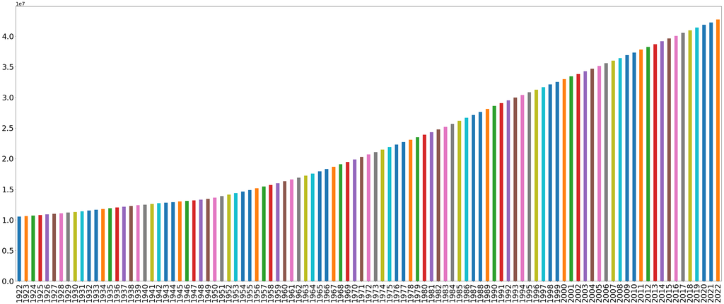

```python
mean.plot(kind='bar',fontsize=30,figsize=(50,20));
```

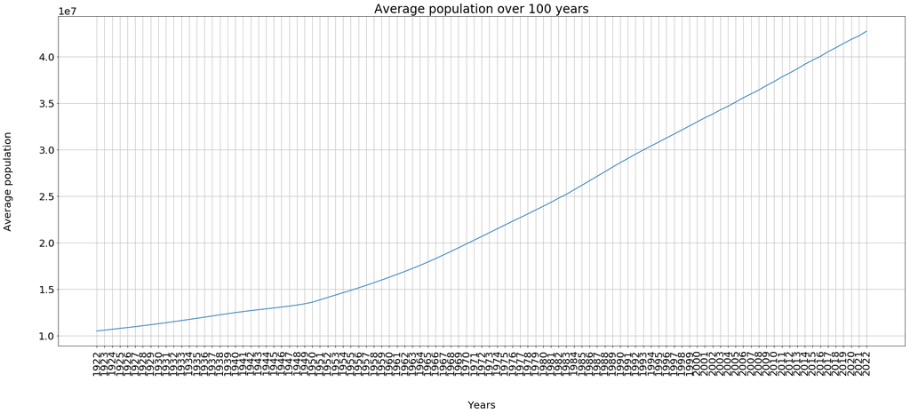

```python
plt.figure(figsize=(30,12))
plt.rcParams['font.size']=20
plt.plot(list(mean.index),list(mean))
plt.xticks(rotation=90);
plt.grid()
plt.title('Average population over 100 years')
plt.xlabel('Years')
plt.ylabel('Average population');
```

### Research Question 2 (Is expected that population will increase in following years ?)

```python
column_filter_2=df_population.columns[-28:]
```

```python
mean_2=df_population.filter(items=column_filter_2).mean()
```

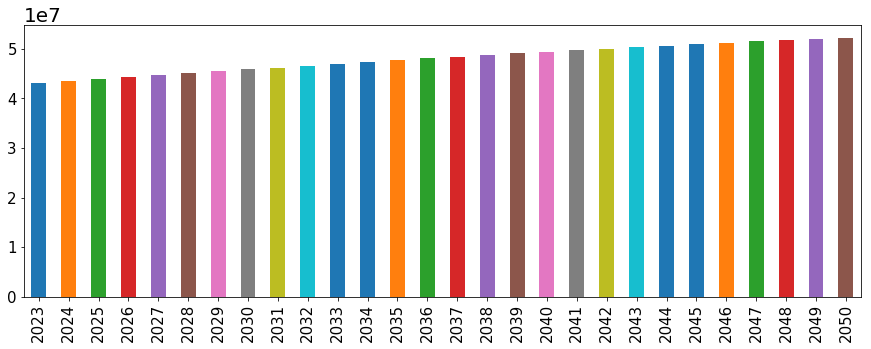

```python
mean_2.plot(kind='bar',fontsize=15,figsize=(15,5));
```

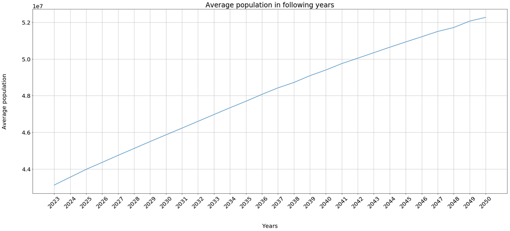

```python
plt.figure(figsize=(30,12))
plt.rcParams['font.size']=20
plt.plot(list(mean_2.index),list(mean_2))
plt.xticks(rotation=45);
plt.grid()
plt.title('Average population in following years')
plt.xlabel('Years')
plt.ylabel('Average population');
```

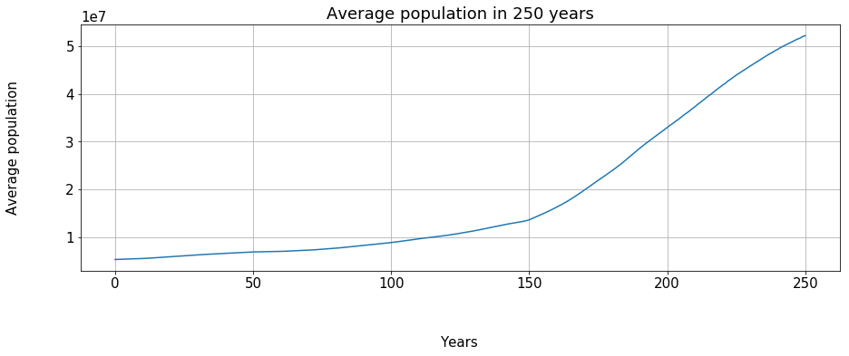

```python
plt.figure(figsize=(15,5))
plt.rcParams['font.size']=15
plt.plot(list(df_population.mean()))
plt.grid()
plt.title('Average population in 250 years')
plt.xlabel('Years')
plt.ylabel('Average population');
```

### Research Question 4 (Is average income per person of all countries increase by years in past 100 years ?)

since income dataframe has the same columns as population dataframe we don't need th make column filteration again, we will use population filteration

```python
mean_3=df_income.filter(items=column_filter).mean()
```

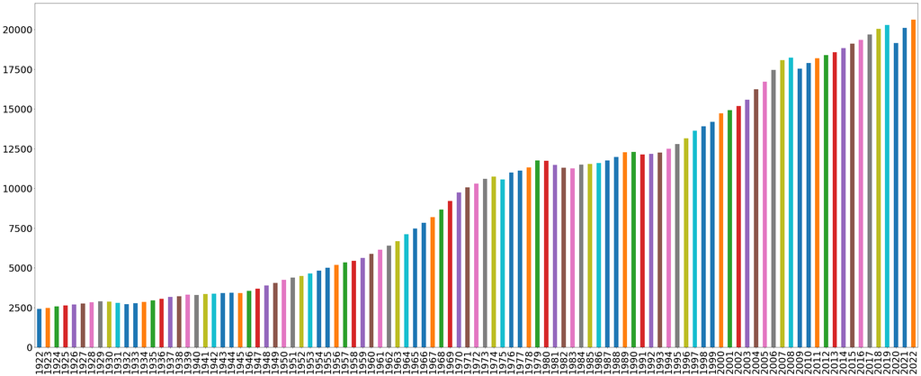

```python
mean_3.plot(kind='bar',fontsize=30,figsize=(50,20));
```

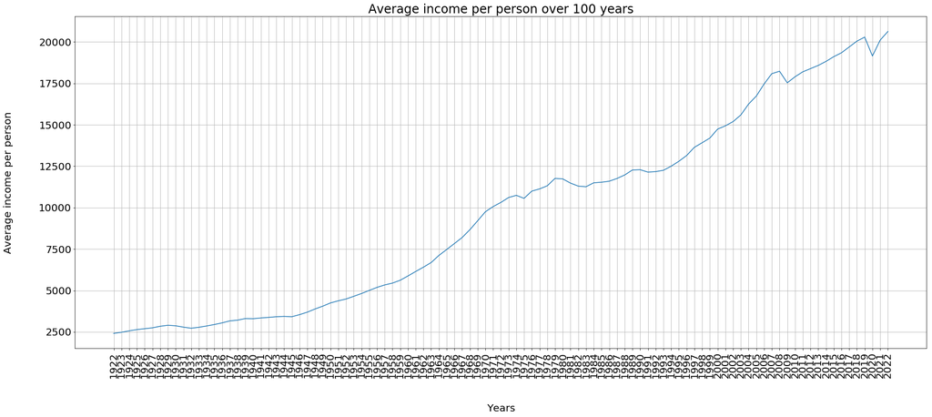

```python
plt.figure(figsize=(30,12))
plt.rcParams['font.size']=20
plt.plot(list(mean_3.index),list(mean_3))
plt.xticks(rotation=90);
plt.grid()
plt.title('Average income per person over 100 years')
plt.xlabel('Years')
plt.ylabel('Average income per person');
```

### Research Question 5 (Is expected that income per person will increase in following years ?)

since income dataframe has the same columns as population dataframe we don't need th make column filteration again, we will use population filteration

```python
mean_4=df_income.filter(items=column_filter_2).mean()
```

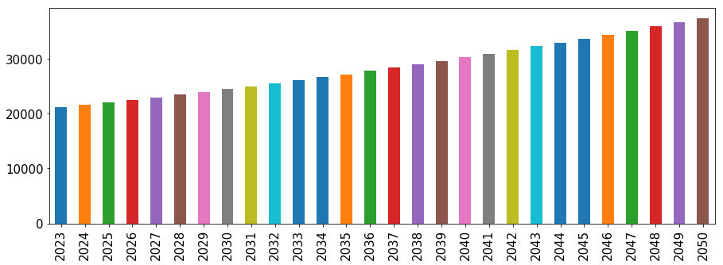

```python
mean_4.plot(kind='bar',fontsize=15,figsize=(15,5));
```

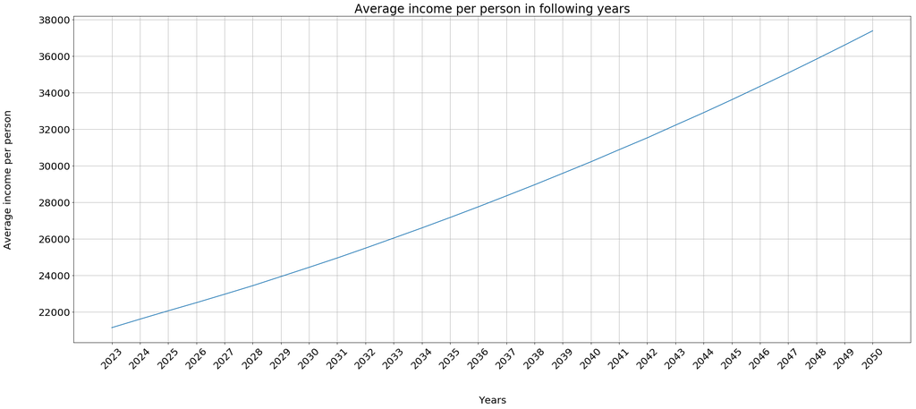

```python
plt.figure(figsize=(30,12))
plt.rcParams['font.size']=20
plt.plot(list(mean_4.index),list(mean_4))
plt.xticks(rotation=45);
plt.grid()
plt.title('Average income per person in following years')
plt.xlabel('Years')
plt.ylabel('Average income per person');
```

So if we combined all past and future years of income per person indicator from year 1800 to year 2050 we will find that the income have increased from less than 2,500 to more than 37,000

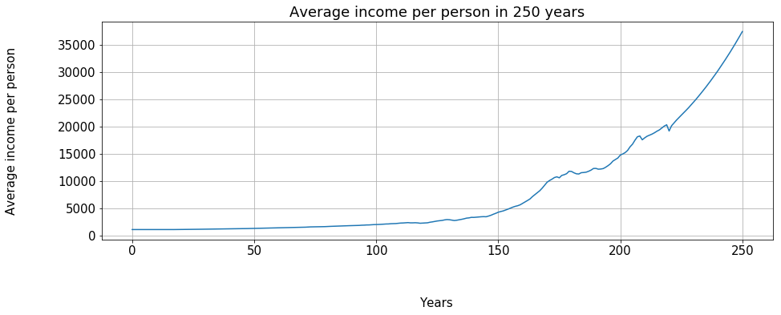

```python
plt.figure(figsize=(15,5))
plt.rcParams['font.size']=15
plt.plot(list(df_income.mean()))
plt.grid()
plt.title('Average income per person in 250 years')
plt.xlabel('Years')
plt.ylabel('Average income per person');
```

### Research Question 6 (Is average life expectancy of all countries increase by years in past 100 years ?)

since life expectancy dataframe has the same columns as population dataframe we don't need th make column filteration again, we will use population filteration

```python
mean_5=df_life.filter(items=column_filter).mean()
```

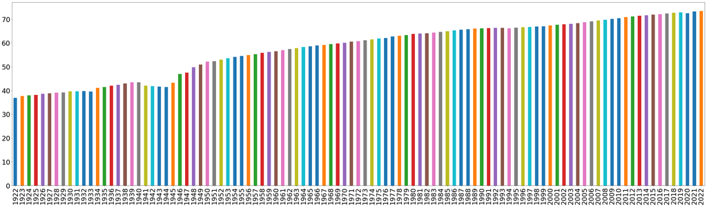

```python
mean_5.plot(kind='bar',fontsize=30,figsize=(55,15));
```

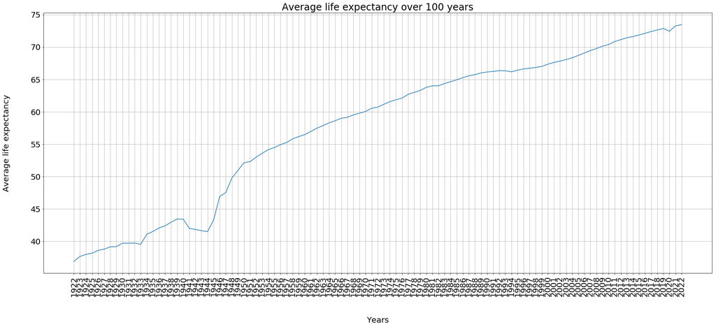

```python
plt.figure(figsize=(30,12))
plt.rcParams['font.size']=20
plt.plot(list(mean_5.index),list(mean_5))
plt.xticks(rotation=90);
plt.grid()
plt.title('Average life expectancy over 100 years')
plt.xlabel('Years')
plt.ylabel('Average life expectancy');
```

### Research Question 7 (Is expected that life expectancy will increase in following years ?)

since life expectancy dataframe has the same columns as population dataframe we don't need th make column filteration again, we will use population filteration

```python
mean_6=df_life.filter(items=column_filter_2).mean()
```

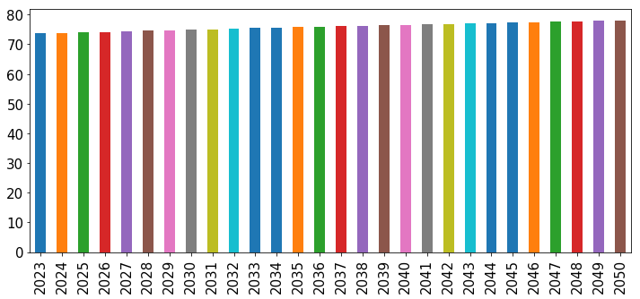

```python
mean_6.plot(kind='bar',fontsize=15,figsize=(12,5));
```

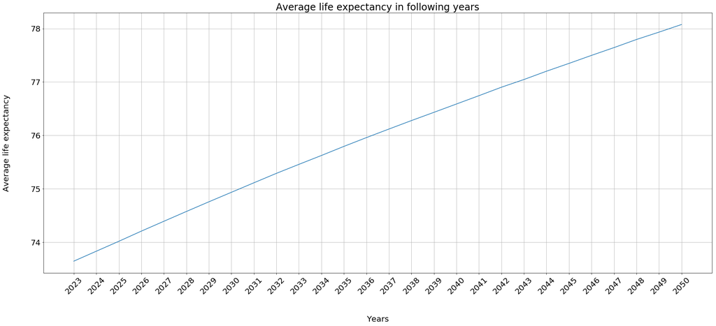

```python
plt.figure(figsize=(30,12))
plt.rcParams['font.size']=20
plt.plot(list(mean_6.index),list(mean_6))
plt.xticks(rotation=45);
plt.grid()
plt.title('Average life expectancy in following years')
plt.xlabel('Years')
plt.ylabel('Average life expectancy');
```

So if we combined all past and future years of life expectancy indicator from year 1800 to year 2050 we will find that the life expectancy have increased from less than 40 years to more than 75 years

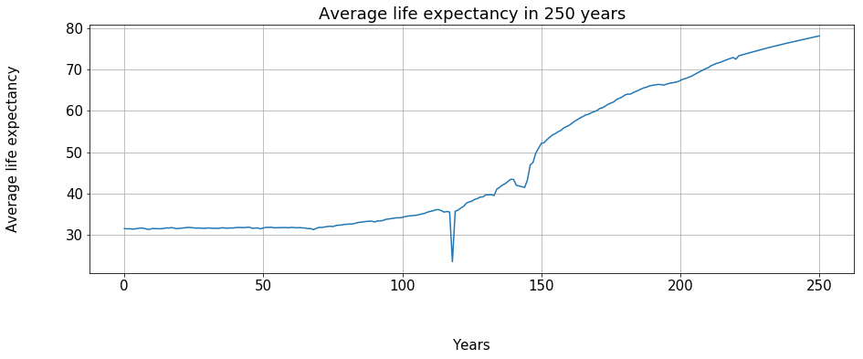

```python
plt.figure(figsize=(15,5))
plt.rcParams['font.size']=15
plt.plot(list(df_life.mean()))
plt.grid()
plt.title('Average life expectancy in 250 years')
plt.xlabel('Years')
plt.ylabel('Average life expectancy');
```

### Research Question 8 (What is the relationship between income indicator and population and life expectancy indicators ?)

First we need to get average income per person and average population and average life expectancy of all 186 countries each year

```python
mean_income=df_income.mean()
```

```python
mean_life=df_life.mean()
```

```python
mean_population=df_population.mean()
```

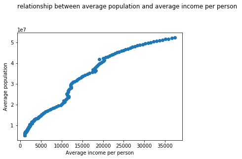

```python
plt.scatter(x=mean_income,y=mean_population)
plt.xlabel('Average income per person')
plt.ylabel('Average population')
plt.title('relationship between average population and average income per person ',y=1.2,loc='left');
```

so there's a positive relationship between income per person indicator and popualtion indicator

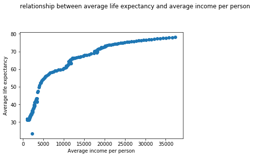

```python
plt.scatter(x=mean_income,y=mean_life)
plt.xlabel('Average income per person')
plt.ylabel('Average life expectancy')
plt.title('relationship between average life expectancy and average income per person ',y=1.2,loc='left');
```

so there's a positive relationship between income per person indicator and life expectancy indicator

## limitation

> there were some countries that didn't have any values so I had to remove them from income dataframe and population dataframe,which may effect the results and produce inacurate statistics.

```python
from subprocess import call
call(['python', '-m', 'nbconvert', 'Investigate Gapminder world Dataset.ipynb'])
```

```
0
```